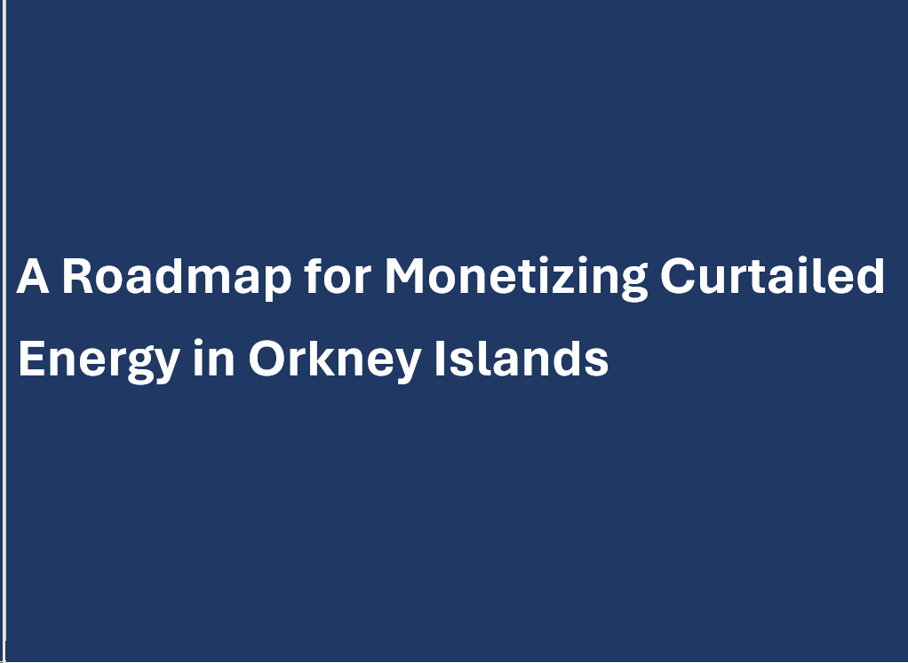

# Table of Contents

*(Clickable links provided for each section)*

### 1. Executive Summary

### 2. Introduction

### 3. Technologies and Techniques

A. Unveiling the Current Landscape: Processing and Analysing Wind Energy and Residential Demand Data

B. Exploring Household Demand Dynamics: Analysing Seasonality

C. Exploring Wind Speed Variations: Hourly and Monthly Trends

D. Wind Power Potential: Is the Rousay Wind Turbine Operating at Full Capacity?

E. Wind Energy Utilisation: Analysing Generation and Consumption

### 4. Bridging the Gap: Exploring Solutions for Wind Energy Curtailment

A. How can Wind Energy be better utilised?

B. How do we plan on achieving that?

C. Business Model

D. Financial Evaluation: Should Kaluza pursue this project?

E. Beyond Kaluza - Empowering the Community

### 5. Conclusion

### 6. Limitations

### 7. References

### 8. Appendix

A. Appendix 1: Turbine Telemetry Data Pre-processing

B. Appendix 2: Residential Demand Data Pre-processing

C. Appendix 3: Financial Model

# Executive Summary

The Orkney Islands in Scotland are at the forefront of renewable energy, producing electricity well beyond their needs. Based on our thorough analysis of sample residential demand and turbine generation data, we estimate over 40% of Orkney's potential wind energy is curtailed due to inadequate grid capacity and low demand relative to supply, leading to significant energy waste and financial losses of around £10.5m annually. Accompanying this renewable energy abundance, Orkney Islands suffers severe fuel poverty faced by more than 60% of Orkney's residents. To address these challenges, our report proposes an analytics-driven business model leveraging Kaluza's product offerings to monetize lost energy for wind farmers and provide more affordable and flexible energy for residents.

Our proposed solution centers on revolutionising residential heating with Kaluza's Demand-Response (DR) System, which requires no grid infrastructure modifications. By utilizing advanced analytics and IoT, this system optimizes energy usage by syncing surplus energy with demand, enabling households to store and utilize excess energy during peak wind periods, thereby reducing losses and benefiting all stakeholders.

We meticulously developed a financial model to outline the roadmap for implementing this transformation and projecting its outcomes. The project spans 24 months, during which Kaluza will proactively interact with local stakeholders through awareness campaigns, wind farmer onboarding, and collaboration with councils and government entities. Incentives will be provided to encourage household adoption, a key aspect of our financial analysis. Multiple stress scenarios were explored to understand performance variations with different adoption rates (penetration ratios). With a 44% adoption ratio, our base scenario penetration ratio, around 4,700 households will access affordable clean energy, generating £3 million in annual revenue for wind farmers, and yielding a £2.7 million profit for Kaluza within the 24-month timeline with breakeven during the 10th month. Additionally, revenue and profit streams will continue beyond the initial two years due to ongoing fees from wind farmers. As the penetration ratio declines, so does the project's financial attractiveness for Kaluza, ultimately resulting in zero profit by the end of year 2 when the penetration ratio hits 13%. We firmly believe that the penetration ratio will be significantly higher than this threshold, given the compelling value proposition that benefits all stakeholders and propels the project toward success.

As with any research endeavour, our analysis and findings are not immune to uncertainties, ranging from data challenges to financial assumptions. The limitations of our study and results will be elaborated upon in the "Limitations" section presented later in the report.

# Introduction

Orkney Islands, a leader in generation of renewable energy, faces a pressing challenge concerning energy curtailment. Limited by the interconnectors’ capacity and the cable connections used for export, some of the energy is currently curtailed (lost) to balance the power system. This arises from constraints in the capacity of interconnectors and cable connections utilised for export, resulting in the loss of surplus energy to maintain system equilibrium. This issue underscores a broader dilemma accompanying the transition to renewable energy sources like wind and solar, characterized by their inherent variability and limited controllability compared to traditional fossil fuel power plants.

In this report, we aim to quantify the magnitude and cost of the annual curtailed energy as well as identify the drivers and patterns of curtailment which will enable us to recommend a detailed solution using Kaluza's product offerings that would monetise the wasted energy in a manner that benefits stakeholders along the supply chain, including Kaluza, the wind farmers, the consumers (Orkney Households), and the government.

In our analytical pursuit, we anticipate distinct patterns and seasonality in both energy generation and curtailment, which may not align with the seasonal demand fluctuations observed over typical day-to-day or yearly cycles. Should our hypothesis hold true, it would pave the way for the implementation of a Demand-Response system, wherein residential devices are automatically managed to flexibly consume more of the renewable energy can be implemented.

# Technologies and Techniques

To rigorously test our hypothesis, a comprehensive analysis of the available data is necessary. The dataset comprises of telemetry data from a single wind turbine located on the Orkney Islands, with a generation capacity of 900 kW. Additionally, it includes average demand data sampled from various Orkney Islands households at different time intervals.

The primary objective of the analysis is to accurately estimate the annually curtailed energy. To achieve this overarching goal, several sub-objectives need to be fulfilled:

- Estimation of Potential Energy Generation: Determining the maximum energy output that the turbine could potentially generate.
- Examination of Seasonality and Patterns of Average Residential Demand: Studying the typical demand patterns of households to determine consumption trends.
- Examination of Seasonality and Patterns of Wind Speed: Studying the typical wind speed patterns over the year and during the day as this would influence the turbine generation patterns.

Once an estimate of the curtailed energy is obtained, the subsequent step involves identifying the underlying seasonality and patterns to formulate practical solutions. However, prior to starting the analysis, a thorough exploration and understanding of the two datasets are essential. This preliminary stage will involve scrutiny of the data to identify and address any potential data issues, including entry errors and missing values, ensuring the reliability and accuracy of the subsequent analysis.

## A- Unveiling the Current Landscape: Processing and Analysing Wind Energy and Residential Demand Data

In this section, our focus is on processing and inspecting the two key datasets: Turbine Telemetry Data and Residential Demand Data. The primary objective is to ready the data for analysis and insights extraction, acknowledging the crucial role of this step in ensuring the accuracy and reliability of our final results. This data cleaning phase serves as the foundation of our research, paving the way for robust analyses and the subsequent development of effective curtailment energy monetization strategies based on dependable datasets.

This section will display the main findings and actions taken. The detailed code and analysis is included in the Appendix.

### A.1 - A Glimpse into Wind Generators: Rousay Island Wind Turbine

We first examined the Turbine Telemetry Dataset. The data includes a timestamp at a second granularity, the average amount of power generated during the time interval (measured in kilowatts), the setpoint representing the mean-maximum possible generator output during the time interval (measured in kilowatts), and the mean wind speed during the time interval (measured in meters per second).

Each column maintained the correct data type. However, the dataset contained null values and missing readings. The main findings and the specific modifications made, along with the motivations for each adjustment, are outlined below.

In terms of missing values, 0.5% of the data had null values, and the correlation matrix below shows a notable correlation exists between missing wind speed and corresponding power measurement, suggesting potential telemetry errors during specific time intervals. Consequently, we opted to drop these rows, considering the insignificance of the percentage out of the full dataset.

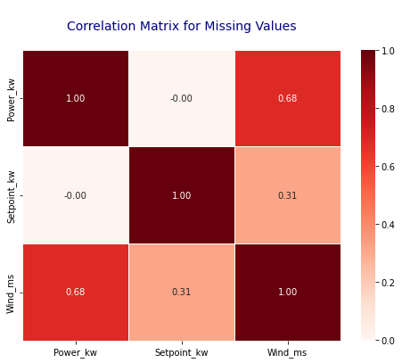

```python
corr_matrix_tt
```

Moving on to understanding the readings included in the data. Upon initial observation of the dataset, it appears that the readings are captured at 1-minute intervals. However, this hypothesis required validation, thus the distribution of time difference between consecutive readings was examined, which is shown in the table below. This analysis revealed that 98.5% of measurements are taken at regular one-minute intervals, providing a high level of confidence about our hypothesis. About 0.8% deviates by one second, which is deemed acceptable and aligns with the 1-minute time interval hypothesis.

```python
print("\nFrequency Table of Time Differences:\n")
display(frequency_table)
```

```
Frequency Table of Time Differences:
```

|  | Time Difference | Frequency | Percentage |
| --- | --- | --- | --- |
| 0 | 0 days 00:01:00 | 1049127 | 98.581963 |
| 1 | 0 days 00:01:01 | 4305 | 0.404522 |
| 2 | 0 days 00:00:59 | 4181 | 0.392871 |
| 3 | 0 days 00:02:00 | 2168 | 0.203718 |
| 4 | 0 days 00:00:04 | 1124 | 0.105617 |
| ... | ... | ... | ... |
| 146 | 0 days 00:15:01 | 1 | 0.000094 |
| 147 | 0 days 00:14:59 | 1 | 0.000094 |
| 148 | 0 days 00:00:37 | 1 | 0.000094 |
| 149 | 0 days 00:00:23 | 1 | 0.000094 |
| 150 | 0 days 01:08:00 | 1 | 0.000094 |

151 rows × 3 columns

Employing the one-minute interval assumption, we generated a date range spanning from the minimum to the maximum dates to identify missing readings. Based on the one-minute interval assumption, we expected an average of 43K readings per month. To visualize the amount of missing entries per month, we plotted a bar chart plot that showed the frequency of readings per month. Entries predating January 2016, which are majorly missing data, were filtered out, with the assumption that this period was potentially a testing phase where the turbine may not have operated at full capacity. In April 2017 and January 2018, the readings were less than 50% of the expected readings count for the whole month. It would not be accurate to generate synthetic readings for those months, so, for that reason it was decided to ignore those months in the analysis.

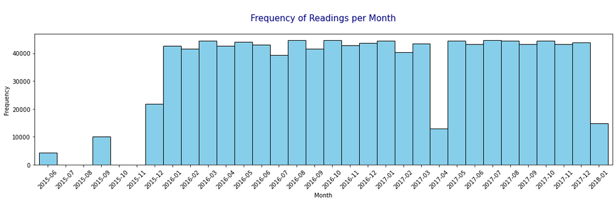

```python
plot1_readingsfrequency
```

```python
summary_comparison
```

|  | Original Telemetry Stats Power_kw | Original Telemetry Stats Setpoint_kw | Original Telemetry Stats Wind_ms | Resampled Telemetry Stats Power_kw | Resampled Telemetry Stats Setpoint_kw | Resampled Telemetry Stats Wind_ms |
| --- | --- | --- | --- | --- | --- | --- |
| count | 1007421 | 1007421 | 1007421 | 1004943 | 1004943 | 1004943 |
| mean | 361 | 807 | 9 | 361 | 808 | 9 |
| std | 338 | 264 | 5 | 338 | 264 | 5 |
| min | 0 | 0 | 0 | 0 | 0 | 0 |
| 25% | 48 | 900 | 6 | 48 | 900 | 6 |
| 50% | 244 | 900 | 8 | 244 | 900 | 8 |
| 75% | 687 | 900 | 12 | 687 | 900 | 12 |
| max | 938 | 900 | 47 | 938 | 900 | 47 |

The final step involved addressing missing readings for months where the missing readings count constitutes less than 0.13% of the overall readings, rendering it statistically insignificant. Upon visualising the missing values for each month, we saw that typically consecutive days are missing. While this might suggest maintenance activities, considering that wind turbines are typically serviced annually rather than monthly, it is reasonable to assume that the reader was broken while the power supply remained intact. Therefore, a reasonable approach would be to fill in these points by averaging values based on the year, month, and hour, utilising these calculated values to fill in the corresponding timestamps. The time series below shows how for January and July 2016 readings are missing consecutively (13-14th of January, and 25-29th of July).

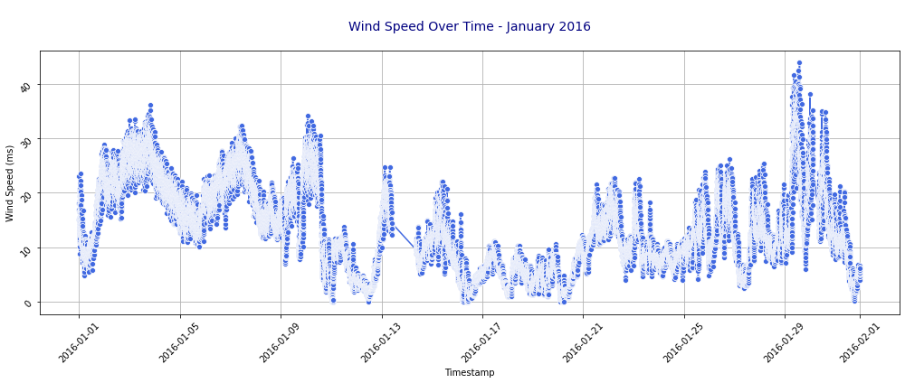

```python
jan2016wind
```

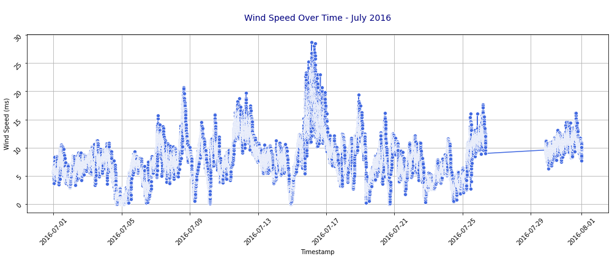

```python
july2016wind
```

Finally, we assessed the setpoint efficacy by examining the alignment between setpoint and actual power generation. Ideally, during network operator-enforced curtailment, generated power should consistently match or be below the setpoint. However, we acknowledge the potential for slight exceedance —assumed to be up to 10%— due to unforeseen operational factors or system dynamics. The data shows that there are only 2.44% of the readings with power exceeding 110% of the setpoint value, for which we cap the values for the power field at the setpoint.

**The detailed code used to process and clean the Turbine Telemetry Data is included in Appendix 1.**

### A.2 - Orkney Islands Residential Demand

Moving on to the other side of the equation, the Residential Demand data includes a timestamp at a second granularity, the average demand during the time interval (measured in kilowatts), and the number of households included in the statistics of the measurement time interval. All columns had the correct data type, and no missing values were detected. Upon inspection, it appeared the readings are captured at a 30-minute intervals with no discrepancies or missing readings as exhibited in the turbine telemetry data.

The main modification made to this dataset was related to outliers. Therefore, the focus of this section is explaining the procedure taken to address outliers.

The summary statistics revealed notable outliers in the data, particularly in the maximum value for the number of households, which stands at 30,000 (significantly higher than the published 2011 households count). Such extreme values are indicative of potential data errors or multiple readings for the same households.

Below is the summary statistics of the residential demand dataset.

```python
summary_statistics
```

|  | Demand_mean_kw | N_households |
| --- | --- | --- |
| count | 17568.000 | 17568.000 |
| mean | 0.219 | 8630.642 |
| std | 0.090 | 2999.142 |
| min | 0.087 | 5406.000 |
| 25% | 0.144 | 6781.000 |
| 50% | 0.212 | 8190.500 |
| 75% | 0.274 | 9652.000 |
| max | 0.510 | 30037.000 |

The irregular spikes and dips observed in the number of households during July 2017, September 2017, November 2017, December 2017, and January 2018 were deemed to be data anomalies due to their abrupt fluctuations, which lack a sensible rationale. These anomalous entries were replaced with values that align with the gradual upward trend evident in the dataset.

Here, we note that the observed increasing trend in household numbers does not accurately reflect the evolution of population of the Orkney Islands. According to the published 2011 Scotland Census data, the number of households in 2011 was reported as 9,725. Therefore, it is highly improbable that by 2017, the number of households would have dropped to 5,000 and then subsequently increased every 30 minutes to reach the 10,000 households mark by 2018. This discrepancy suggests that the data represents a growing sample of households included in the data collection and processing over the course of the year, possibly due to the gradual installation of smart meters in households, enabling the gradual capture of household data.

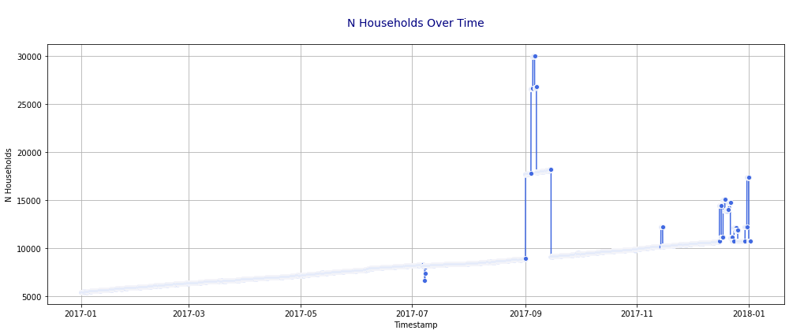

```python
plot_households
```

Given the anomalies present in the number of households we defined a threshold of 100 to identify significant deviations in the number of households movement in consecutive readings, considering any movement beyond this threshold as an anomaly. Subsequently, a procedure was implemented to replace these anomalies with values that adhere to the gradual upward linear trend. This involved creating a copy of the original data, and iterating through the dataset to detect anomalies. Once identified, the code selected the preceding smoothed readings, applied a linear model, and predicted values along the linear trend. These smoothed values were then used to replace the anomalous entries. By updating the 'N_households' column with the smoothed data, this process aimed to enhance the overall consistency of the dataset and mitigate the impact of outliers on subsequent analyses where a demand weighted average is calculated for less granular time intervals, such as hours or days. The graph below shows the final result of this process, it can be seen that the outliers have been removed and now the data follows a smoothed upward trend.

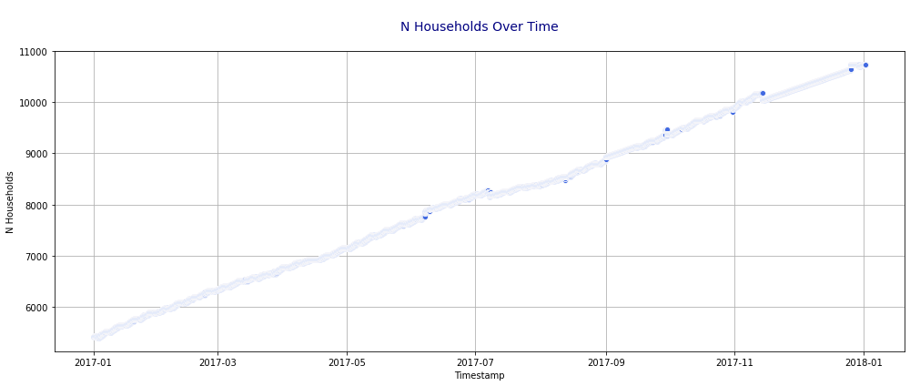

```python
smoothed_households
```

To conclude the data exploration of the residential demand data, we examined the distribution of mean demand over the course of a year. This revealed a clear monthly seasonality, peaking in winter and reaching lows in summer. This pattern aligns with typical UK electricity consumption patterns, where there is an increased demand for electricity during colder periods, primarily for heating and lighting purposes. Conversely, during the summer months, electricity demand tends to decrease as temperatures do not necessitate extensive use of air conditioning or other cooling systems like some other countries/regions.

Further, the series of boxplots shown below provided confidence in data reliability, given that no outliers or extreme values are observed.

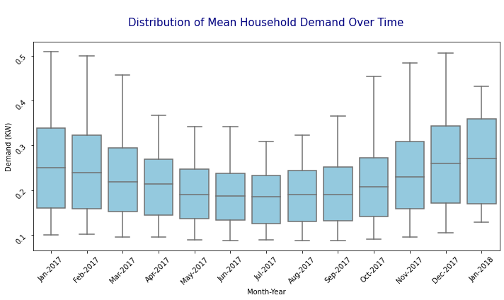

```python
demand_histogram
```

**The detailed code used to process and clean the Residential Demand Data is included in Appendix 2.**

Now that we are confident of the data quality, the focus of the next section is dissecting the demand seasonality over the day and over the week.

## B- Exploring Household Demand Dynamics: Analysing Seasonality

We investigated the variations in average household demand throughout the day and across the days of the week. To accomplish this, we computed the weighted mean demand per day, month, and hour, considering both the demand mean in kilowatts per reading and the number of households. This involves defining new date-related variables and calculating the weighted mean for each reading as $\small{\text{ Demand_mean_kw per reading } * \text{ Number of Households}}$.

```python
residential_demand['Month'] = residential_demand['Timestamp'].dt.strftime('%B')

residential_demand['Hour'] = residential_demand['Timestamp'].dt.hour

residential_demand['Weekday'] = residential_demand['Timestamp'].dt.strftime('%A')
day_order = ['Monday', 'Tuesday', 'Wednesday', 'Thursday', 'Friday', 'Saturday', 'Sunday']
residential_demand['Weekday'] = pd.Categorical(residential_demand['Weekday'], categories=day_order, ordered=True)

residential_demand['Weighted_Mean_Demand'] = residential_demand['Demand_mean_kw'] * residential_demand['N_households']
```

### B.1 - Demand Patterns over 24 Hours

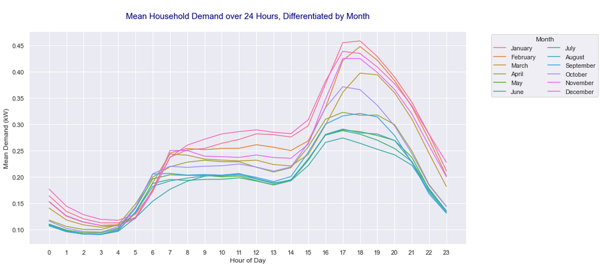

```python
# Calculate weighted average mean demand per hour
hourly_mean_demand = residential_demand.groupby(['Month', 'Hour'])['Weighted_Mean_Demand', 'N_households'].sum()
hourly_mean_demand['Mean_Demand_per_Hour'] = hourly_mean_demand['Weighted_Mean_Demand'] / hourly_mean_demand['N_households']


# Set the order of months for plotting
month_names_ordered = residential_demand['Month'].unique()

# Define a color palette
month_palette = sns.color_palette("husl", len(month_names_ordered))

# Plot mean demand per hour during each month of the year
sns.set_theme()
plt.figure(figsize=(14, 7))

for i, month in enumerate(month_names_ordered):
    monthly_data = hourly_mean_demand.loc[month]
    plt.plot(monthly_data.index, monthly_data['Mean_Demand_per_Hour'], label=f'{month}', color=month_palette[i])

plt.title('\nMean Household Demand over 24 Hours, Differentiated by Month\n', size=15, color="navy")
plt.xlabel('Hour of Day')
plt.ylabel('Mean Demand (kW)')
plt.legend(title = "Month", labels=  month_names_ordered, bbox_to_anchor=(1.05, 1), loc='upper left', ncol=2)
plt.xticks(range(0, 24))

plt.show()
```

Typically, residential demand exhibits a cyclical pattern characterized by peak and off-peak periods, as evidenced in each month's line plot. These periods can be described as follows:

- Midnight to Early Morning (Pre-Dawn Hours): Demand remains relatively low during the early morning hours as residents are asleep, resulting in minimal energy usage. Consumption during this time primarily accounts for essential appliances like refrigerators and heating systems.
- Morning to Afternoon: Demand gradually rises during the morning hours as occupants engage in daily routines and prepare for the day, which can be seen around hours 5-7. Peak energy consumption occurs during mid-morning to early afternoon when households are fully active, and consumption remains relatively stable till late afternoon (around 2 pm - hour 14).
- Late Afternoon to Evening (Peak Period): The highest demand is observed in the late afternoon to early evening as residents return home from work or school, typically around 6 pm (hour 18). This period, known as the "evening peak", sees simultaneous usage of lighting, cooking appliances, entertainment devices, and heating systems.
- Evening to Night: Demand gradually declines in the evening as households wind down activities, have dinner, and prepare for bedtime. Consumption further decreases during late night and early morning hours as residents sleep, resulting in the day's lowest demand levels, and then the cycle is repeated.

Seasonal variations also influence demand patterns across different months. For instance, the severity of the evening peak is more pronounced during winter months compared to summer months. This difference can be attributed to increased lighting usage due to earlier sunsets and heightened heating demand to combat low temperatures during winter.

We next investigated the variations in the average household demand over the 24 hours of the day during different week days.

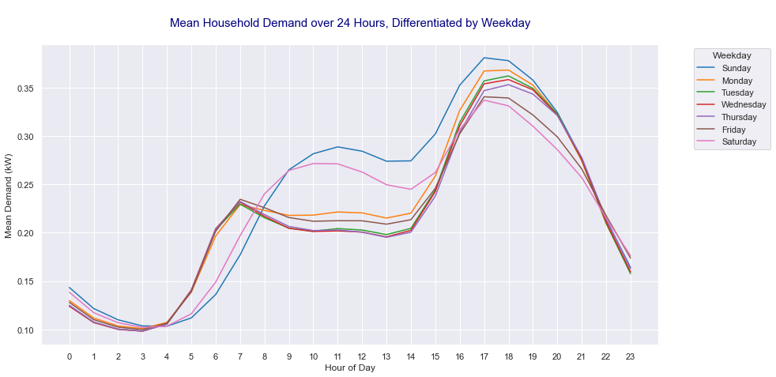

```python
# Calculate weighted average mean demand per hour
hourly_mean_demand = residential_demand.groupby(['Weekday', 'Hour'])['Weighted_Mean_Demand', 'N_households'].sum()
hourly_mean_demand['Mean_Demand_per_Hour'] = hourly_mean_demand['Weighted_Mean_Demand'] / hourly_mean_demand['N_households']


# Set the order of months for plotting
day_names_ordered = residential_demand['Weekday'].unique()

# Define a color palette
day_palette = sns.color_palette("tab10", len(day_names_ordered))

# Plot mean demand per hour during each month of the year
sns.set_theme()
plt.figure(figsize=(14, 7),facecolor='white')

for i, day in enumerate(day_names_ordered):
    day_data = hourly_mean_demand.loc[day]
    plt.plot(day_data.index, day_data['Mean_Demand_per_Hour'], label=f'{day}', color=day_palette[i])

plt.title('\nMean Household Demand over 24 Hours, Differentiated by Weekday\n', size=15, color="navy")
plt.xlabel('Hour of Day')


plt.ylabel('Mean Demand (kW)')
plt.legend(title = "Weekday", labels = day_names_ordered, bbox_to_anchor=(1.05, 1), loc='upper left')
plt.xticks(range(0, 24))

plt.show()
```

Analysing the average household demand by week day reveals another layer of consumption behaviour. While the overall pattern remains consistent, further segmentation by weekdays sheds light on distinct consumption patterns influenced by workdays (Monday to Friday).

On workdays (or school days), we observe a peak in demand during the morning to early afternoon hours, particularly around 6-7 am. This peak gradually decreases to a stable rate throughout the late afternoon. While weekends exhibit a delayed peak in demand, occurring around 10-11 am. This delay is logical considering that many individuals tend to wake up later on weekends and commence their daily activities at a later hour compared to workdays. During late afternoon to evening hours, consistent patterns are observed across both weekdays and weekends, as discussed previously.

### B.2 - Demand Patterns over the Week

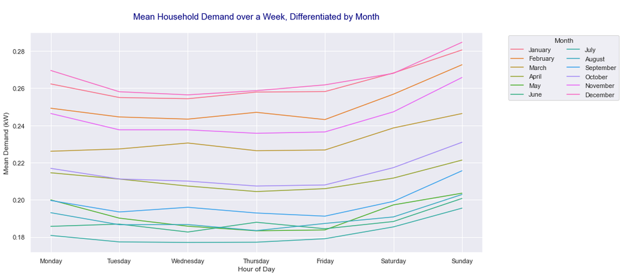

```python
# Calculate weighted average mean demand per day of the week
daily_mean_demand = residential_demand.groupby(['Month', 'Weekday'])['Weighted_Mean_Demand', 'N_households'].sum()
daily_mean_demand['Mean_Demand_per_Weekday'] = daily_mean_demand['Weighted_Mean_Demand'] / daily_mean_demand['N_households']



# Plot mean demand per hour during each month of the year
sns.set_theme()
plt.figure(figsize=(14, 7))

for i, month in enumerate(month_names_ordered):
    monthly_data = daily_mean_demand.loc[month]
    plt.plot(monthly_data.index, monthly_data['Mean_Demand_per_Weekday'], label=f'{month}', color=month_palette[i])

plt.title('\nMean Household Demand over a Week, Differentiated by Month\n', size=15, color="navy")
plt.xlabel('Hour of Day')
plt.ylabel('Mean Demand (kW)')
plt.legend(title = "Month", labels = month_names_ordered, bbox_to_anchor=(1.05, 1), loc='upper left', ncol=2)


plt.show()
```

Our examination of household electricity demand over the week days revealed intriguing cyclical trends. Traditionally, one would expect higher demand on weekdays compared to weekends. However, focusing specifically on residential demand, we uncovered a unique pattern. Peak demand occurs on Sundays, followed by Saturdays.

This deviation from the expected weekday peak can be attributed to the dynamics of residential energy consumption. During weekends, especially on Sundays, households typically experience higher occupancy levels as residents spend more time at home engaging in various activities. This increased presence leads to greater utilisation of home appliances, lighting, heating, and other amenities, consequently driving up electricity demand.

In contrast, weekdays often see lower residential demand due to work and school commitments, resulting in many occupants being away from home for significant portions of the day.

This observation highlights the importance of considering specific contexts when analysing energy demand patterns, especially in addressing the energy curtailment conundrum that we will delve into quantifying in later sections of this report. Understanding these nuances is vital for accurately assessing the issue and devising effective solutions.

The next section includes a similar analysis of the wind speed of the sample turbine to explore its seasonality patterns.

## C- Exploring Wind Speed Variations: Hourly and Monthly Trends

We examined how wind speed changes throughout the day and month, expecting shifts due to weather patterns in addition to daily changes, particularly expecting higher speeds at night.

```python
# Extract month, hour, and weekday from the timestamp
complete_tt_resampled['Month'] = complete_tt_resampled['Timestamp'].dt.strftime('%B')
complete_tt_resampled['Month'] = pd.Categorical(complete_tt_resampled['Month'], categories=complete_tt_resampled['Month'].unique(),
                                             ordered=True)

complete_tt_resampled['Hour'] = complete_tt_resampled['Timestamp'].dt.hour
```

### C.1 - Wind Speed during the Day

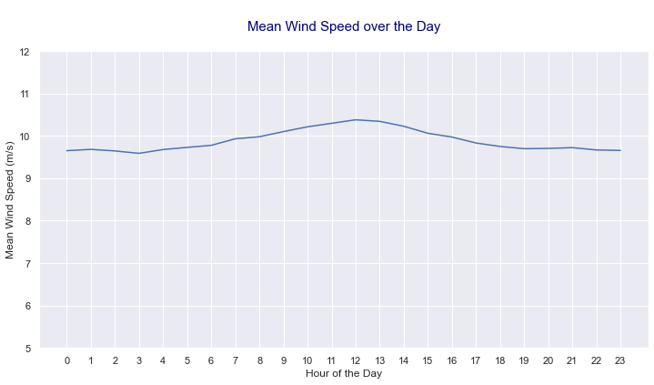

```python
# Group the data by hour, calculate the mean wind speed
grouped_data = complete_tt_resampled.groupby(['Hour'])['Wind_ms'].mean().reset_index()


# Create a white background figure
sns.set_theme()
plt.figure(figsize=(12, 6), facecolor='white')

# Create a line plot using seaborn with the custom color palette
sns.lineplot(data=grouped_data, x='Hour', y='Wind_ms')



plt.title('\nMean Wind Speed over the Day\n', size= 15, color = "navy")
plt.xlabel('Hour of the Day')
plt.ylabel('Mean Wind Speed (m/s)')
plt.xticks(range(24))
plt.ylim(5,12)

plt.show()
```

Contrary to our assumptions, the peak in wind speed occurs during daytime hours, notably around noon, rather than during the night. Nonetheless, the overall average wind speed remains relatively consistent throughout the day, a characteristic that might align with the geographical conditions of island environments.

### C.2 - Wind Speed during the Year

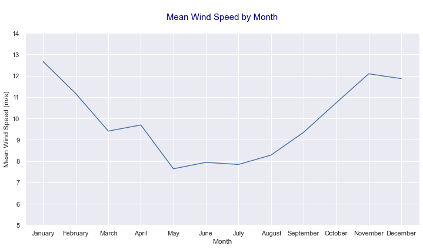

```python
# Group the data by hour, calculate the mean wind speed
grouped_data = complete_tt_resampled.groupby(['Month'])['Wind_ms'].mean().reset_index()


# Create a white background figure
sns.set_theme()
plt.figure(figsize=(12, 6), facecolor='white')

# Create a line plot using seaborn with the custom color palette
sns.lineplot(data=grouped_data, x='Month', y='Wind_ms')



plt.title('\nMean Wind Speed by Month\n', size= 15, color = "navy")
plt.xlabel('Month')
plt.ylabel('Mean Wind Speed (m/s)')
plt.ylim(5,14)


plt.show()
```

We observe fluctuations in wind speeds throughout the year, suggesting a recurring seasonal pattern. Peaks in wind speed, possibly indicating more turbulent weather conditions, concentrate in the winter months. These spikes may correspond to seasonal storms or the frequent passage of weather fronts during this timeframe. Conversely, summer months exhibit a period of relative calm characterized by fewer and less intense wind speed spikes, reflecting the typically milder weather patterns of this season.

## D- Wind Power Potential: Is the Rousey Wind Turbine Operating at Full Capacity?

$$\text{Wind Energy} = \frac{1}{2} \times m \times v^2 \text {, where m is the air mass and v is the wind speed} \hspace{50pt} \text { Formula (1)}$$

Air mass can be estimated based on the air density $\rho$ and air volume $V$, transforming the formula to $$\text{Wind Energy} = \frac{1}{2} \times V \times \rho \times v^2 \hspace{50pt} \text { Formula (2)}$$

Now in this scenario, we were looking to estimate the potential **power** that can be generated. Therefore, we needed to transform the formula to be on a power basis. Taking into account that power energy divided by a time period, then the power can be estimated as

$$\text {Wind Power} = \frac{\Delta \text{Wind Energy}}{\Delta t} = \frac{\frac{1}{2} \times \Delta V \times \rho \times v^2}{\Delta t} \hspace{50pt} \text { Formula (3)}$$

$\Delta V$ can be replaced with $A \times v \times \Delta t$, where $v\Delta t$ is the distance travelled by air particles over a small period of time and $A$ is the rotor area of the wind turbine.

Replacing $\Delta V$ by $A \times v \times \Delta t$ finally yields $$\text {Wind Power} = \frac{1}{2} \times \rho \times A \times v^3 \hspace{50pt} \text { Formula (4)}$$

Where

- $\rho$ is the air density
- $A$ is the rotor area of the wind turbine
- $v$ is the wind speed

Given that the data includes one wind turbine, we can assume that $A$ is a fixed, unknown variable. The air density $\rho$, however, can vary based on meteorological factors such as temperature, pressure, and humidity. Therefore, we expect that the estimate for $\rho$ would vary at least by calendar month. In our analysis we will treat $A \times \rho$ as one factor to estimate.

*Sources:*

- *https://home.uni-leipzig.de/energy/energy-fundamentals/15.htm#:~:text=The%20wind%20power%20increases%20with,important%20for%20a%20wind%20turbine*
- *https://energyeducation.ca/encyclopedia/Wind_power*
- *https://www.sciencedirect.com/science/article/pii/S2352484722011854#fig2*

Beyond wind speed and air density, additional factors play a crucial role in determining the potential power or energy output of a wind turbine. These factors include safety protocols and the minimum wind speed necessary to initiate turbine operation. Typically, wind turbines remain inactive until they reach a certain "cut-in speed", beyond which a cubic relationship, as described by Formula (4), governs power generation up to a "rated speed". Beyond this rated speed, power output stabilizes/plateaus until the turbine reaches its "cut-out speed", where power generation ceases altogether. These rated and cut-out speeds serve as safety measures to ensure the turbine operates within safe and efficient parameters. Therefore, the Power Function becomes a piece-wise function:

$${\text{Wind Power}} = \begin{cases} 0 & v \leq \text{cut-in speed} \\ \frac{1}{2} \times \rho \times A \times v^3 \hspace{50pt} & \text{cut-in speed}\leq v \leq \text{rated speed} \\ \frac{1}{2} \times \rho \times A \times \text{rated speed}^3 \hspace{50pt} & \text{rated speed}\leq v \leq \text{cut-out speed} \\ 0 & v \geq \text{cut-out speed}\\ \end{cases} \hspace{50pt} \text {Formula (5)}$$

The objective of this section is to estimate the factor $A \times \rho $ factor in Formula (5). To do so, our analysis started with visualising the wind speed and power relationship in the turbine telemetry dataset. By visually inspecting the data, we were able to determine the cut-in speed, rated speed, and cut-out speed. Subsequently, we focused on estimating the power curve parameters between the cut-in and rated speeds.

### D.1 - Observed Wind Speed and Power Relationship

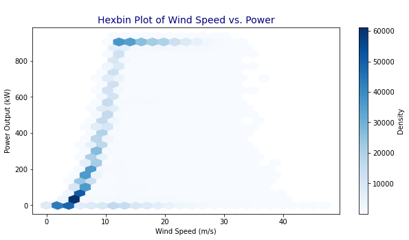

```python
sns.reset_orig()
plt.figure(figsize=(10, 5))

plt.hexbin(x=turbine_telemetry_resampled['Wind_ms'], y=turbine_telemetry_resampled['Power_kw'],
           gridsize=25, cmap='Blues', mincnt=1)

plt.xlabel('Wind Speed (m/s)')
plt.ylabel('Power Output (kW)')
plt.title('\nHexbin Plot of Wind Speed vs. Power',  size= 14, color="navy")


plt.colorbar(label='Density')
plt.show()
```

Upon initial observation, it seems that the cut-in speed lies at or below the 5 m/s threshold, while the rated speed is positioned at or above the 10 m/s threshold. Additionally, the cut-out speed seems to fall within the 25-30 m/s range. It also appears that there are instances where the generated power is 0 within the range of the cut-in speed to cut-out speed, which might indicate that the turbine was turned off during that period. Consequently, these instances will be omitted during the power curve parameter estimation phase to ensure accurate function fitting.

Prior to this exclusion, we estimated the three knots (changing points): cut-in speed, rated speed, and cut-out speed. started with determining the cut-in speed by analysing the cumulative distribution of zero power generation within the wind speed interval of 0 to 6 m/s. This analysis aimed to pinpoint a suitable wind speed threshold below which the majority of zero power generation instances occur.

*Cut-in Speed*

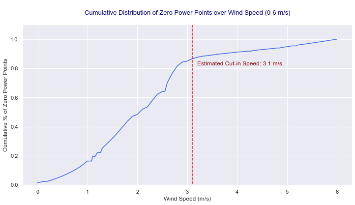

```python
# Identify zero power points
zero_power_points = turbine_telemetry_resampled[(turbine_telemetry_resampled['Power_kw'] == 0)
                                               &
                                               (turbine_telemetry_resampled['Wind_ms'] <= 6)]

# Calculate the percentage of zero power points for each unique wind speed value
percentage_zero_power = zero_power_points.groupby('Wind_ms')['Power_kw'].count() / zero_power_points.shape[0]
# Calculate cumulative distribution
cumulative_percentage = percentage_zero_power.sort_index().cumsum()

# Plot cumulative distribution
sns.set_theme()
plt.figure(figsize=(12, 6))
plt.plot(cumulative_percentage.index, cumulative_percentage.values, linestyle='-', color = "royalblue")
plt.vlines(x=cumulative_percentage[cumulative_percentage > 0.85].index[0], ymin=-0.1, ymax=1.1, color="red",
           linestyle="--", linewidth=1.5)
plt.text(cumulative_percentage[cumulative_percentage > 0.85].index[0] + 0.1, 0.82,
         f'Estimated Cut-in Speed: {cumulative_percentage[cumulative_percentage >= 0.85].index[0]} m/s',
         horizontalalignment='left', color = "darkred", size= 12)



plt.xlabel('Wind Speed (m/s)')
plt.ylabel('Cumulative % of Zero Power Points')
plt.title('\nCumulative Distribution of Zero Power Points over Wind Speed (0-6 m/s)\n', size = 13, color = "navy")
plt.grid(True)
plt.ylim(0, 1.1)
plt.show()
```

Analysing the plot, we observed that the cumulative distribution exhibits a rapid slope until it reaches a wind speed of around 3 m/s, after which the rate of increase decreases. We have decided to identify the cut-in speed at which the cumulative distribution exceeds 85% as this is where it appears the slope changes, which is found to be 3.1 m/s.

```python
cut_in_speed = cumulative_percentage[cumulative_percentage > 0.85].index[0]
cut_in_speed
```

```
3.1
```

Our subsequent analysis aimed to estimate the rated speed and cut-out speed using a similar approach. However, instead of examining the distribution of zero generated power, we focused on the distribution of maximum power generated by the turbine. This rationale for being is that we expect that the power generated at the rated speed represents the maximum output achievable by the turbine. Consequently, we sought to identify the wind speed below which a majority of the instances of maximum power generation occur. As for the cut-out speed determination, our goal was to identify the wind speed below which nearly all instances of maximum power generation are recorded, effectively reaching close to 100% occurrence.

*Rated Speed and Cut-out Speed*

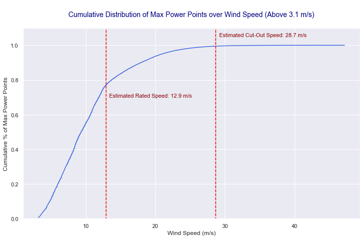

```python
# Identify zero power points
max_power_points = turbine_telemetry_resampled[(turbine_telemetry_resampled['Power_kw'] >= np.max(turbine_telemetry_resampled['Power_kw']*0.95))
                                               |
                                               (turbine_telemetry_resampled['Power_kw'] <= np.max(turbine_telemetry_resampled['Power_kw']*1.05))
                                               &
                                               (turbine_telemetry_resampled['Wind_ms'] > cut_in_speed)]

percentage_max_power = max_power_points.groupby('Wind_ms')['Power_kw'].count() / \
max_power_points.shape[0]

# Calculate cumulative distribution
cumulative_percentage = percentage_max_power.sort_index().cumsum()

# Plot cumulative distribution
sns.set_theme()
plt.figure(figsize=(12, 7))
plt.plot(cumulative_percentage.index, cumulative_percentage.values,  linestyle='-', color = "royalblue")
plt.vlines(x=cumulative_percentage[cumulative_percentage > 0.77].index[0], ymin=-0.1, ymax=1.1, color="red",
           linestyle="--", linewidth=1.5)
plt.text(cumulative_percentage[cumulative_percentage > 0.77].index[0] + 0.25, 0.70,
         f' Estimated Rated Speed: {cumulative_percentage[cumulative_percentage >= 0.77].index[0]} m/s',
         horizontalalignment='left', color = "darkred", size = 11)


plt.vlines(x=cumulative_percentage[cumulative_percentage > 0.995].index[0], ymin=-0.1, ymax=1.1, color="red",
           linestyle="--", linewidth=1.5)
plt.text(cumulative_percentage[cumulative_percentage > 0.995].index[0] + 0.25, 1.05,
         f' Estimated Cut-Out Speed: {cumulative_percentage[cumulative_percentage >= 0.995].index[0]} m/s',
         horizontalalignment='left', color = "darkred", size = 11)


plt.xlabel('Wind Speed (m/s)')
plt.ylabel('Cumulative % of Max Power Points')
plt.title(f'\nCumulative Distribution of Max Power Points over Wind Speed (Above {cut_in_speed} m/s)\n',
          size= 14, color = "navy")
plt.grid(True)
plt.ylim(0, 1.1)
plt.show()
```

```python
rated_speed = cumulative_percentage[cumulative_percentage > 0.77].index[0]

rated_speed
```

```
12.9
```

```python
cut_out_speed = cumulative_percentage[cumulative_percentage > 0.995].index[0]

cut_out_speed
```

```
28.7
```

*Power Curve*

After identifying the three "knots" in the power function described by Formula (5), we moved forward to create the power curve by estimating the combined factors of $A \times \rho$.

We constructed a generalized power curve using data from all time periods. Since we had established that power is consistently zero below the cut-in speed or above the cut-out speed, and that it is capped at the potential power when exceeding the rated speed up to the cut-out speed, our focus shifted to determining the factor influencing potential power generation within the wind speed range of the cut-in and rated speeds.

```
618490 points (61.27%) of all readings are included in the dataset to be used to estimate the power curve.
```

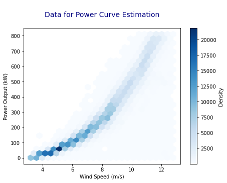

```python
# Exclude inefficient points - curtailed by setpoint
power_curve_df =  complete_tt_resampled[complete_tt_resampled['Power_kw'] <=
                                        (1-setpoint_grace_factor) * complete_tt_resampled['Setpoint_kw']]

# Limit the data to wind speeds between cut-in speed and rated speed to reduce noise
power_curve_df =  power_curve_df[(power_curve_df['Wind_ms'] > cut_in_speed)
                                 &
                                (power_curve_df['Wind_ms'] < rated_speed)]

# Exclude 0 power points between cut-in speed and rated speed
power_curve_df =  power_curve_df[(power_curve_df['Power_kw'] != 0) ]



# Print information about the subset
print(f"\n{power_curve_df.shape[0]} points ({round(power_curve_df.shape[0]/complete_tt_resampled.shape[0]*100,2)}%)",
      "of all readings are included in the dataset to be used to estimate the power curve.\n")



##_________________________________________________________________________________________________________________________##



# Plot the data that will be used in the power curve estimation
sns.reset_orig()
plt.figure(figsize=(7, 5))


plt.hexbin(x=power_curve_df['Wind_ms'], y=power_curve_df['Power_kw'],
           gridsize=25, cmap='Blues', mincnt=1)

plt.xlabel('Wind Speed (m/s)')
plt.ylabel('Power Output (kW)')
plt.title('\nData for Power Curve Estimation\n',  size= 14, color="navy")


plt.colorbar(label='Density')
plt.show()
```

With the suitable data, we then moved to estimating the factor $A \times \rho$.

```
Optimized Factor rhoA: 0.9373598116352749
```

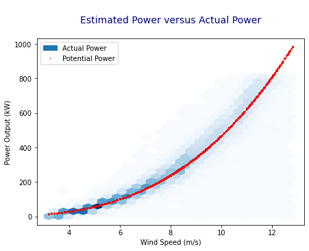

```python
np.random.seed(42)

#Define power function that calculates potential power given a wind speed
def wind_power_function(v, cut_in_speed, rated_speed, cut_out_speed, rhoA):
    """
    Piecewise function representing wind power based on wind speed.

    Args:
    v (array-like): Wind speed.
    cut_in_speed (float): Cut-in speed of the wind turbine.
    rated_speed (float): Rated speed of the wind turbine.
    cut_out_speed (float): Cut-out speed of the wind turbine.
    rhoA (float): Product of air density and rotor area.

    Returns:
    array-like: Wind power.
    """
    wind_power = np.zeros_like(v)
    wind_power = np.where((v > cut_in_speed) & (v <= rated_speed), 0.5*rhoA*v**3, 0.5*rhoA*rated_speed**3)


    return wind_power


##_________________________________________________________________________________________________________________________##


# Estimate A x rho
initial_guess = 1

popt, pcov = curve_fit(wind_power_function, power_curve_df['Wind_ms'].values, power_curve_df['Power_kw'].values,
                           p0=[cut_in_speed, rated_speed, cut_out_speed, initial_guess],
                           bounds=([cut_in_speed, rated_speed, cut_out_speed, 0],
                                   [cut_in_speed+0.01, rated_speed+0.01, cut_out_speed+0.01, np.inf]))

optimized_rhoA = popt[3]

print("\nOptimized Factor rhoA:", optimized_rhoA, '\n')


# Generate potential power using the estimated factor
power_curve_df['Potential_power_kw'] = 0.5 * optimized_rhoA * np.minimum(power_curve_df['Wind_ms'] , rated_speed)**3


##_________________________________________________________________________________________________________________________##

# Plot the the estimated power against the actual power generated for the ideal points
sns.reset_orig()
plt.figure(figsize=(7, 5))

plt.hexbin(x=power_curve_df['Wind_ms'], y=power_curve_df['Power_kw'],
           gridsize=25, cmap='Blues', mincnt=1, label = 'Actual Power')


plt.scatter(power_curve_df['Wind_ms'], power_curve_df['Potential_power_kw'], color='red', label='Potential Power', s= 0.5)


plt.xlabel('Wind Speed (m/s)')
plt.ylabel('Power Output (kW)')
plt.title('\nEstimated Power versus Actual Power\n',  size= 14, color="navy")
plt.legend()


plt.show()
```

The estimated power curve closely matches the observed power generated at the ideal points. Consequently, we utilised this function across all telemetry readings to estimate the potential power generation for each instance. By comparing this estimation with the actual power generated, we aimed to quantify the extent of unrealised power. To conclude, the estimated power function is:

### D.2 - Total Potential Power

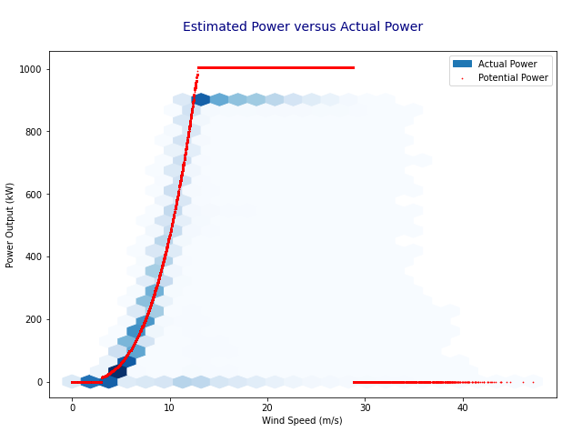

```python
# Generate potential power using the estimated factor
complete_tt_resampled['Potential_power_kw'] = 0.5 * optimized_rhoA * \
np.where((complete_tt_resampled['Wind_ms'] < cut_in_speed) | (complete_tt_resampled['Wind_ms'] > cut_out_speed),
         0,
         np.minimum(complete_tt_resampled['Wind_ms'] , rated_speed)) **3


##_________________________________________________________________________________________________________________________##

# Plot the the estimated power against the actual power generated for the ideal points
plt.figure(figsize=(10, 7))

plt.hexbin(x=complete_tt_resampled['Wind_ms'], y=complete_tt_resampled['Power_kw'],
           gridsize=25, cmap='Blues', mincnt=1, label = 'Actual Power')


plt.scatter(complete_tt_resampled['Wind_ms'], complete_tt_resampled['Potential_power_kw'], color='red', label='Potential Power', s= 0.5)


plt.xlabel('Wind Speed (m/s)')
plt.ylabel('Power Output (kW)')
plt.title('\nEstimated Power versus Actual Power\n',  size= 14, color="navy")
plt.legend()

plt.show()
```

Upon comparing the actual generated power to its potential, it appeared that the Rousay Islands Wind Turbine is operating near its maximum capacity. However, the setpoint acts as a limiting factor, hindering the turbine from reaching its full potential. This suggests that the setpoint is influenced not only by safety turbine measures but also by grid infrastructure factors, storage capacity, and interconnection capacity.

## E- Wind Energy Utilisation: Analysing Generation and Consumption

This section consolidates all the necessary elements for assessing the extent of wind energy curtailment, if present. Energy curtailment encompasses two categories: unrealised power, resulting from enforced restrictions by the turbine and grid capacity (typically enforced by the setpoint), and under-consumption of generated energy, occurring when supply surpasses demand and potential export. We will examine the entire spectrum, covering both types of curtailment, before focusing on the relevant type or both, and exploring potential solutions.

It was crucial to consider several key points here:

- The supply data available is for one wind turbine with measurements at one minute intervals. This means that we need to estimate the supply from all wind turbines in Orkney Islands.
- The demand available is the average demand per household with measurements at 30 minute intervals. This means that we need to estimate the total residential demand for all the households in Orkney Islands
- Both sides of the are power-based measured at the kilowatt unit, not energy-based. Firstly, this means that we need to convert to energy, which is simply Power multiplied by time. Additionally, for simpler display of values, we will transform the unit of measurement to be Megawatt instead of kilowatt.

As for the time scales, business decisions and planning are often done on a larger timescale, such as hourly or daily. Additionally, too low time intervals would lead to too much noise in the analysis. Therefore, we aggregated the data to an **hourly** basis thus ensuring that the analysis is directly relevant to business objectives and decision-making processes. Therefore, to conclude, the final unit of measurement for Energy will be Megawatt Hour.

As for export, according to the Orkney Renewable Energy Forum Audit, the exported wind energy is around 60 GWh (60,000 MWh) per year. For simplicity, this amount was split evenly over all hours during the year.

### E.1 - Quantifying Wind Energy Generation and Energy Consumption in Orkney Islands

*Hourly Energy Calculation Methodology*

**Residential Demand per Household**

$\small{\text{Half-Hourly Household Energy Demand (MWh)} = \text{Mean Household Power (MW) per 30 minutes} \times \frac{1}{2}}$

$\small{\text{Hourly Household Energy Demand (MWh)} = \text{Sum of Energy for the two consecutive 30-minute intervals of the hour}} $

**Total Hourly Residential Demand**

$\small{\text{Total Hourly Energy Demand (MWh)} = \text{Hourly Household Energy Demand (MWh)} \times \text{Number of Households in Orkney Islands}} $

**Supply per Turbine**

$\small{\text{Minute Turbine Energy Supply (MWh)} = \text{Mean Power (MW) per 1 minute} \times \frac{1}{60} }$

$\small{\text{Hourly Turbine Energy Supply (MWh)} = \text{Sum of Energy for the 60 consecutive 1-minute intervals of the hour} }$

**Total Hourly Wind Supply**

$\small{\text{Total Hourly Energy Supply (MWh)} = \text{Hourly Turbine Energy Supply (MWh)} \times \text{Number of Turbines in Orkney Islands} \times \text{Capacity Adjustment Factor} \times \text{Operational Adjustment Factor}}$

- *Capacity Adjustment Factor: After researching the wind turbines in Orkney Islands, we found 33 large-scale turbines with a total capacity of 44.4K KW, and around 500 domestic turbines, each with an average capacity of 6KW. Considering that the turbine data we have is for a turbine with a capacity of 900KW, we calculated an adjustment factor that scales its generation power to a weighted average of all turbine capacities. This capacity adjustment was determined to be **0.0988**.*
- *Operational Adjustment Factor: Additionally, recognizing that not all wind turbines operate at the same level at all times due to varying meteorological conditions across geographical areas in the Orkney Islands, we included an arbitrary operational adjustment factor of **0.95**.*

*Assumptions*

**Number of Households**

The total number of households is taken to be the maximum number of households in the dataset.

```python
num_households = np.max(residential_demand['N_households'])
num_households
```

```
10735.0
```

**Turbines Assumptions**

```python
num_turbines = 533
capacity_adjustment_factor = 0.0988
operational_adjustment_factor = 0.95
```

**Export Assumptions**

```python
export_MWh = 60000 / 365 / 24
print(f"Export assumed per hour: {export_MWh} Mwh")
```

```
Export assumed per hour: 6.8493150684931505 Mwh
```

**Unit of Measurements Conversion Parameters**

```python
minutes_to_hour = 1/60
half_hour_to_hour = 1/2
KW_to_MW = 1/1000
```

*Total Hourly Residential Energy Demand*

```python
# Convert Power to Megawatt
residential_demand['Demand_mean_mw'] = KW_to_MW * residential_demand['Demand_mean_kw']

# Convert half-hourly power to half-hourly energy
residential_demand['Demand_mean_mwh'] = half_hour_to_hour * residential_demand['Demand_mean_mw']

# Aggregate by hour
residential_demand_hr = residential_demand.set_index('Timestamp').resample('H').sum().reset_index()
residential_demand_hr.drop(['Demand_mean_kw', 'Demand_mean_mw', 'N_households', 'Household_Movement', 'Weighted_Mean_Demand'],
                           axis=1, inplace= True)

# Check Aggregation
print(f"\nDifference in Energy before and after aggregation = \
      {(np.sum(residential_demand['Demand_mean_mwh'])-np.sum(residential_demand_hr['Demand_mean_mwh'])).astype(int)}\n")


# Estimate total demand for all households
residential_demand_hr['Demand_mwh'] = num_households * residential_demand_hr['Demand_mean_mwh']

residential_demand_hr.drop(['Demand_mean_mwh'],
                           axis=1, inplace= True)

# residential_demand_hr.head(10)
```

```
Difference in Energy before and after aggregation =       0
```

```python
residential_demand_hr.describe()
```

|  | Hour | Demand_mwh |
| --- | --- | --- |
| count | 8784.000000 | 8784.000000 |
| mean | 23.000000 | 2.351936 |
| std | 13.845161 | 0.962539 |
| min | 0.000000 | 0.931043 |
| 25% | 11.500000 | 1.550804 |
| 50% | 23.000000 | 2.274890 |
| 75% | 34.500000 | 2.934192 |
| max | 46.000000 | 5.442933 |

```python
print(f"\nThe average demand for all households per hour is {np.mean(residential_demand_hr['Demand_mwh']):.1f} MWh.")
```

```
The average demand for all households per hour is 2.4 MWh.
```

*Total Hourly Wind Energy Supply*

```python
# Convert Power to Megawatt
complete_tt_resampled['Power_mw'] = KW_to_MW * complete_tt_resampled['Power_kw']
complete_tt_resampled['Potential_power_mw'] = KW_to_MW * complete_tt_resampled['Potential_power_kw']

# Convert minute power to minute energy
complete_tt_resampled['Energy_mwh'] = minutes_to_hour * complete_tt_resampled['Power_mw']
complete_tt_resampled['Potential_energy_mwh'] = minutes_to_hour * complete_tt_resampled['Potential_power_mw']

# Aggregate by hour
aggregation_functions = {
    'Wind_ms': 'mean',
    'Energy_mwh': 'sum',
    'Potential_energy_mwh': 'sum'
}

# Aggregate by hour
wind_supply_hr = complete_tt_resampled.set_index('Timestamp').resample('H').agg(aggregation_functions).reset_index()


# Check Aggregation
print(f"\nDifference in Energy before and after aggregation = \
      {(np.sum(wind_supply_hr['Energy_mwh'])-np.sum(wind_supply_hr['Energy_mwh'])).astype(int)}\n")


# Estimate total supply for all turbines
wind_supply_hr['Total_Energy_mwh'] = num_turbines * capacity_adjustment_factor * \
operational_adjustment_factor * wind_supply_hr['Energy_mwh']

wind_supply_hr['Total_Potential_energy_mwh'] = num_turbines * capacity_adjustment_factor * \
operational_adjustment_factor * wind_supply_hr['Potential_energy_mwh']

wind_supply_hr.drop(['Energy_mwh', 'Potential_energy_mwh'],
                           axis=1, inplace= True)


wind_supply_hr.head(10)
```

```
Difference in Energy before and after aggregation =       0
```

|  | Timestamp | Wind_ms | Total_Energy_mwh | Total_Potential_energy_mwh |
| --- | --- | --- | --- | --- |
| 0 | 2016-01-01 00:00:00 | 13.868333 | 41.548573 | 44.178050 |
| 1 | 2016-01-01 01:00:00 | 16.463333 | 44.782843 | 49.846365 |
| 2 | 2016-01-01 02:00:00 | 12.855000 | 42.048013 | 43.459231 |
| 3 | 2016-01-01 03:00:00 | 11.286667 | 32.651203 | 34.023498 |
| 4 | 2016-01-01 04:00:00 | 8.725000 | 16.730823 | 16.215736 |
| 5 | 2016-01-01 05:00:00 | 9.215000 | 22.545673 | 20.705224 |
| 6 | 2016-01-01 06:00:00 | 8.351667 | 14.621336 | 14.317016 |
| 7 | 2016-01-01 07:00:00 | 9.096667 | 19.986772 | 18.321050 |
| 8 | 2016-01-01 08:00:00 | 8.275000 | 14.471253 | 13.555311 |
| 9 | 2016-01-01 09:00:00 | 7.626667 | 11.121087 | 11.065617 |

```python
print(f"\nThe average wind generation for all turbines per hour is {np.mean(wind_supply_hr['Total_Energy_mwh']):.1f} MWh.")
```

```
The average wind generation for all turbines per hour is 17.1 MWh.
```

```python
# Merge demand and supply data
demand_and_supply_hr = pd.merge(residential_demand_hr, wind_supply_hr, on='Timestamp', how='inner')

# Generate Date-based Columns
demand_and_supply_hr['MonthYear'] = demand_and_supply_hr['Timestamp'].dt.strftime('%B')
demand_and_supply_hr['Month'] = demand_and_supply_hr['Timestamp'].dt.strftime('%b-%Y')
demand_and_supply_hr['Month'] = pd.Categorical(demand_and_supply_hr['Month'], categories=demand_and_supply_hr['Month'].unique(),  ordered=True)
demand_and_supply_hr['Year'] = demand_and_supply_hr['Timestamp'].dt.strftime('%Y')
demand_and_supply_hr['Weekday'] = demand_and_supply_hr['Timestamp'].dt.strftime('%A')
demand_and_supply_hr['Hour'] = demand_and_supply_hr['Timestamp'].dt.hour



# demand_and_supply_hr.head(10)

demand_and_supply_hr['Timestamp'].describe()
```

```
count                    8760
unique                   8760
top       2017-01-01 00:00:00
freq                        1
first     2017-01-01 00:00:00
last      2017-12-31 23:00:00
Name: Timestamp, dtype: object
```

The final dataset includes only the year 2017.

### E.2 - Dissecting Energy Utilisation: 2017 Overview

- **Unrealised Energy** = Total Potential Energy - Total Generated Energy
- **Curtailed Energy** = Total Potential Energy - Total Demand - Total Export
- **Unconsumed Energy** = Total Generated Energy - Total Demand. This is energy that was generated but not consumed by the Orkney Islands Population, some of which can be exported.
- **Curtailed Energy due to Underconsumption** = Unconsumed Energy - Total Export

```python
print(f"\nThe total residential demand during 2017 is {np.sum(demand_and_supply_hr['Demand_mwh']):,.0f} MWh.")


print(f"\nThe total wind generation for all turbines during 2017 is \
{np.sum(demand_and_supply_hr['Total_Energy_mwh']):,.0f} MWh.")
```

```
The total residential demand during 2017 is 20,590 MWh.

The total wind generation for all turbines during 2017 is 164,064 MWh.
```

Evidently, the residential demand estimated from the supplied data is not representative of the full electricity demand in Orkney Islands, as it does not consider the commercial and industrial demand (non-domestic). Therefore, before calculating the curtailment, we grossed up the residential demand by a factor of 3 such that it captures the non-domestic demand too. This assumption was made arbitrarily, so there is room for finetuning.

```python
demand_gross_up_factor =  3
```

```python
demand_and_supply_hr['RES_Demand_mwh'] = demand_and_supply_hr['Demand_mwh']

demand_and_supply_hr['Demand_mwh']  = demand_and_supply_hr['RES_Demand_mwh']  * demand_gross_up_factor
```

```python
# Unrealised Energy
demand_and_supply_hr['unrealised_energy_mwh'] = \
demand_and_supply_hr['Total_Potential_energy_mwh'] - demand_and_supply_hr['Total_Energy_mwh']

# Unconsumed Energy
demand_and_supply_hr['unconsumed_energy_mwh'] = \
demand_and_supply_hr['Total_Energy_mwh'] - demand_and_supply_hr['Demand_mwh']

# Curtailed Energy
demand_and_supply_hr['curtailed_energy_mwh'] = \
demand_and_supply_hr['Total_Potential_energy_mwh'] - demand_and_supply_hr['Demand_mwh']


# Export Energy
demand_and_supply_hr['export_mwh'] =  export_MWh


# Curtailed Energy due to Underconsumption
demand_and_supply_hr['unconsumed_unexported_energy_mwh'] = \
demand_and_supply_hr['unconsumed_energy_mwh'] - demand_and_supply_hr['export_mwh']
```

*2017 Energy Curtailment Overview*

```python
# Calculate values for demand, unconsumed, and unrealised energy
total_demand = demand_and_supply_hr['Demand_mwh'].sum()
total_unconsumed = demand_and_supply_hr['unconsumed_energy_mwh'].sum()
total_unrealised = demand_and_supply_hr['unrealised_energy_mwh'].sum()

# Create labels and corresponding values for the pie chart
labels = ['Electricity Demand: {:.1f}K MWh'.format(total_demand / 1000),
          'Unconsumed Energy: {:.1f}K MWh'.format(total_unconsumed / 1000),
          'Unrealised Energy: {:.1f}K MWh'.format(total_unrealised / 1000)]

sizes = [total_demand, total_unconsumed, total_unrealised]

# Create the pie chart
fig = plt.figure(figsize=(5, 5))
plt.pie(sizes, explode = (0.01, 0.01, 0.005) , labels=labels, autopct='%1.0f%%', startangle=140,
        colors= ["#C7E4DC", "#E0A4A4", "#C9D0D1"], textprops={'fontsize': 11})
plt.title('\nTotal Potential Energy Distribution\n', color = "navy", fontsize = 15)
plt.axis('equal')


potential_energy_plot = fig

plt.close()
```

```python
# Calculate values for export and remaining unconsumed energy
total_export = demand_and_supply_hr['export_mwh'].sum()
total_energy = demand_and_supply_hr['Total_Energy_mwh'].sum()
total_unexported = demand_and_supply_hr['unconsumed_unexported_energy_mwh'].sum()

# set up plot
fig, (ax1, ax2) = plt.subplots(1, 2, figsize=(11, 5))
fig.subplots_adjust(wspace=0)

# pie chart parameters
overall_ratios = [total_demand, total_unconsumed]
labels = ['Electricity Demand: {:.1f}K MWh'.format(total_demand / 1000),
          'Unconsumed Energy: {:.1f}K MWh'.format(total_unconsumed / 1000)]

explode = [0.01, 0.01]
angle = 140
wedges, *_ = ax1.pie(overall_ratios, autopct='%1.1f%%', startangle=angle,
                     labels=labels, explode=explode,
                     colors= ["#C7E4DC", "#E0A4A4"], textprops={'fontsize': 11})

ax1.set_title('\nGenerated Energy Utilisation\n', color = "navy", fontsize = 16)
ax1.axis('equal')

# bar chart parameters
unconsumed_split = [total_export, total_unexported]

unconsumed_labels = ['Exported Energy: {:.1f}K MWh'.format(unconsumed_split[0] / 1000),
                     'Remaining Unconsumed Energy: {:.1f}K MWh'.format(unconsumed_split[1] / 1000)]
bottom = 0
width = 3

x_pos = 7

bc_remaining = ax2.bar(x_pos, unconsumed_split[1], width, bottom=unconsumed_split[0], color='#AE3C3C' , alpha =0.8)
ax2.bar_label(bc_remaining, labels=[f"{unconsumed_split[1] /total_energy :.1%}"], label_type="center")
ax2.text(x_pos+1.3,unconsumed_split[1]*2,unconsumed_labels[1], ha='left', va='center', color='darkred', fontsize = 11)

bc_exported = ax2.bar(x_pos, unconsumed_split[0], width, bottom=0, color='#E0A4A4', alpha = 0.35)
ax2.bar_label(bc_exported, labels=[f"{unconsumed_split[0] / total_energy:.1%}"], label_type="center")
ax2.text(x_pos+1.3, unconsumed_split[0]*0.5,unconsumed_labels[0], ha='left', va='center', color='darkred', fontsize = 11)

ax2.axis('off')
ax2.set_xlim(0, 2.75 * width)

# use ConnectionPatch to draw a horizontal line between the two plots
bar_height = sum(unconsumed_split)

# draw connecting line
con = ConnectionPatch(xyA=(-0.45, bar_height / 2), coordsA=ax2.transData,
                      xyB=(2.75, -0.05), coordsB=ax1.transData, arrowstyle="wedge")
con.set_linewidth(1.5)
con.set_mutation_scale(40)
con.set_color('white')
con.set_edgecolor('#C75D5D')

ax2.add_artist(con)

# Save plot
energy_utilisation_plot = fig

plt.close()
```

We began by analysing the overall curtailment; how much of the potential energy generated is actually realized? It is observed that **15% of wind energy remains unrealized during 2017**, indicating the inefficiencies in wind turbine operations. Additionally, the demand accounts for only 32% of the potential energy that could have been generated.

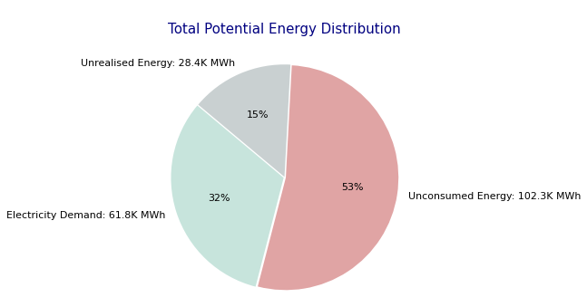

```python
potential_energy_plot
```

**When is the energy wasted the most due to Grid Capacity?**

```python
ratedspeed_percentage_per_month = (demand_and_supply_hr.groupby('Month')
                        .apply(lambda x: np.sum(x['Wind_ms'] >= rated_speed) / len(x['Wind_ms']) * 100)
                        .reset_index(name='Percentage'))

ratedspeed_percentage_per_month['Percentage'] = ratedspeed_percentage_per_month['Percentage'].apply(lambda x: f'{x:.0f}%')

print('\n During {:.0f}% of the year, the wind turbines generation is capped at the rated speed.\n'.format(
    np.sum((demand_and_supply_hr['Wind_ms'] >= rated_speed))/demand_and_supply_hr['Wind_ms'].shape[0]*100 ))


display(ratedspeed_percentage_per_month)
```

```
 During 23% of the year, the wind turbines generation is capped at the rated speed.
```

|  | Month | Percentage |
| --- | --- | --- |
| 0 | Jan-2017 | 35% |
| 1 | Feb-2017 | 39% |
| 2 | Mar-2017 | 30% |
| 3 | Apr-2017 | 0% |
| 4 | May-2017 | 6% |
| 5 | Jun-2017 | 14% |
| 6 | Jul-2017 | 8% |
| 7 | Aug-2017 | 7% |
| 8 | Sep-2017 | 21% |
| 9 | Oct-2017 | 35% |
| 10 | Nov-2017 | 52% |
| 11 | Dec-2017 | 35% |

Then zooming in on the actual generated energy, how much of that generated energy is actually put to use?

- 12.6% are consumed domestically by the households, and 37.7% is assumed to be consumed on domestically and non-domestically
- 36.6% are exported to mainland
- 25.8% remain unconsumed

This means that around **40% of Orkney's Potential Wind energy is curtailed**, representing 70.7k MWh of energy lost annually. Assuming that wind energy can be sold at an average of £0.15 p/KWh, this **amounts to lost revenue of around £10,605,000 lost revenue annually.**

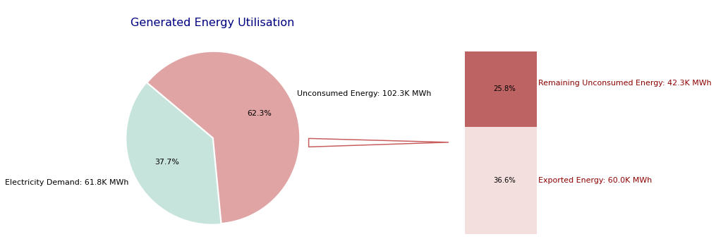

```python
energy_utilisation_plot
```

The analysis provided offered valuable insights into the extent of curtailed energy in Orkney Islands, although it is important to note that the estimate may not be perfectly accurate due to the assumption used to gross up residential demand to get to total demand. Nevertheless, the level of curtailment is alarming.

However, amidst this challenge lies a promising opportunity for improvement. Kaluza's innovative solutions for flexible domestic demand present an avenue to address this issue. By leveraging flexible demand mechanisms, we can effectively absorb a portion of the curtailed energy, mitigating the need for costly infrastructure upgrades. Before proposing a concrete solution, our final analysis explored the relationship between curtailment, demand, and the wind profile.

*2017 Energy Curtailment Profile by Wind Speed*

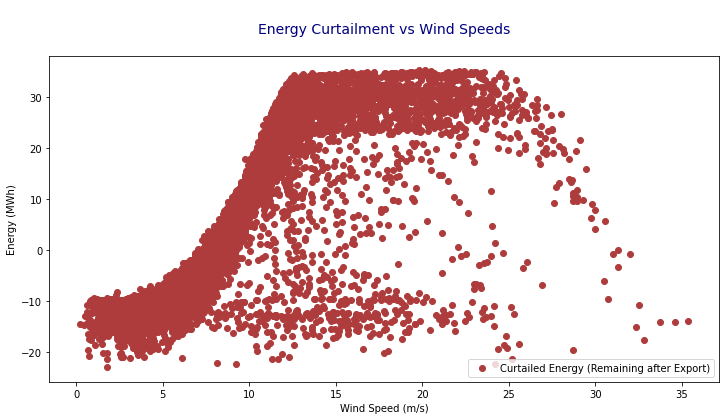

```python
plt.figure(figsize=(12, 6))

plt.scatter(demand_and_supply_hr['Wind_ms'], demand_and_supply_hr['unconsumed_unexported_energy_mwh'],
                 color='#AE3C3C', label='Curtailed Energy (Remaining after Export)')

plt.xlabel('Wind Speed (m/s)')
plt.ylabel('Energy (MWh)')
plt.title('\nEnergy Curtailment vs Wind Speeds\n',  size= 14, color="navy")
plt.legend()

plt.show()
```

We observe a predictable pattern where there is undersupply during periods of insufficient wind speed to power the turbines. However, once the turbines are operational, we see the gap between supply and demand narrow, reaching equilibrium at around a speed of 7.5 m/s. Beyond this point, there is a surplus of energy, leading to curtailment, with the level of curtailed energy increasing proportionally with the wind speed, mirroring the energy x wind curve.

This suggests that a potential solution could involve storing excess energy generated during high wind speed periods for use during times of high demand when wind-generated energy alone is insufficient. During such periods, residents likely resort to alternative energy sources, some of which may be non-renewable like fossil fuels. This leads us to the question: How does the seasonality of wind speed compare to the seasonality of demand?

*Wind Speed and Demand Seasonality By Hour*

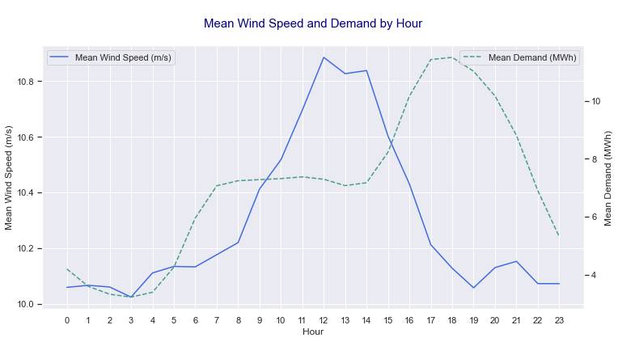

```python
# Group the data by weekday and hour, calculate the mean wind speed
grouped_data_hour = demand_and_supply_hr.groupby(['Hour'])['Wind_ms', 'Demand_mwh'].mean().reset_index()

sns.set_theme()
fig, ax1 = plt.subplots(figsize=(12, 6))
ax2 = ax1.twinx()

# Create line plots for mean wind speed and demand
sns.lineplot(data=grouped_data_hour, x='Hour', y='Wind_ms', ax=ax1, color='royalblue', label='Mean Wind Speed (m/s)')
sns.lineplot(data=grouped_data_hour, x='Hour', y='Demand_mwh', ax=ax2, color='#4A9B83', label='Mean Demand (MWh)', linestyle='dashed')


# Set labels and titles
ax1.set_ylabel('Mean Wind Speed (m/s)')
ax2.set_ylabel('Mean Demand (MWh)')
plt.title('\nMean Wind Speed and Demand by Hour\n', size=15, color='navy')
plt.xlabel('Hour')


# Show legend
lines, labels = ax1.get_legend_handles_labels()
ax1.legend(lines, labels, loc='upper left')

lines2, labels2 = ax2.get_legend_handles_labels()
ax2.legend(lines2, labels2, loc='upper right')

ax2.grid(False)

plt.xticks(range(24))

plt.show()
```

The graph clearly illustrates that the peak mean demand and the peak mean wind speed occur at different times of the day. Specifically, the mean wind speed reaches its zenith between 11 am and 2 pm, while the mean demand peaks from 5 pm to 7 pm. This discrepancy may result in a situation where a significant amount of energy is curtailed between 10 am and 3 pm due to an excess of wind power, whereas from 4 pm to 11 pm, insufficient wind speed may impede the generation of the required power. This behaviour reinforces our initial hypothesis, suggesting that a potential solution could involve energy storage during the morning hours for subsequent use in the afternoon.

*Wind Speed and Demand Seasonality By Month*

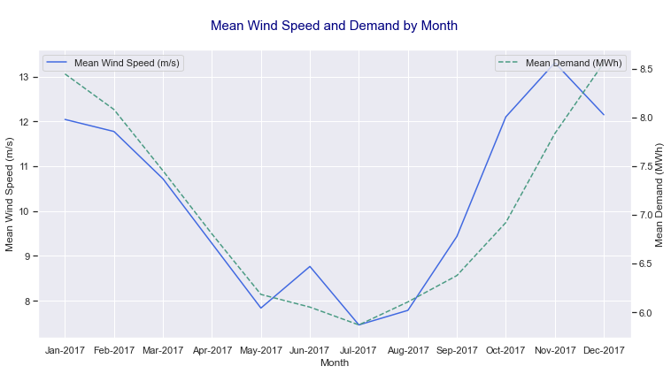

```python
month_names_ordered = demand_and_supply_hr['Month'].unique()
grouped_data = demand_and_supply_hr.groupby(['Month'])['Wind_ms', 'Demand_mwh' ].mean().reset_index()

sns.set_theme()
fig, ax1 = plt.subplots(figsize=(12, 6))
ax2 = ax1.twinx()

# Create line plots for mean wind speed and demand
sns.lineplot(data=grouped_data, x='Month', y='Wind_ms', ax=ax1, color='royalblue', label='Mean Wind Speed (m/s)')
sns.lineplot(data=grouped_data, x='Month', y='Demand_mwh', ax=ax2, color='#4A9B83', label='Mean Demand (MWh)', linestyle='dashed')


# Set labels and titles
ax1.set_ylabel('Mean Wind Speed (m/s)')
ax2.set_ylabel('Mean Demand (MWh)')
plt.title('\nMean Wind Speed and Demand by Month\n', size=15, color='navy')
plt.xlabel('Month')

# Legend
lines, labels = ax1.get_legend_handles_labels()
ax1.legend(lines, labels, loc='upper left')

lines2, labels2 = ax2.get_legend_handles_labels()
ax2.legend(lines2, labels2, loc='upper right')

ax2.grid(False)


plt.show()
```

When we analysed the same variables on a monthly basis, it becomes evident that the seasonality of both wind speed and demand remains consistent throughout the year. This similarity is advantageous for implementing a solution to reduce wind curtailment, as the proposed approach can be applied effectively across all seasons, ensuring its year-round applicability.

*Exploring Energy Generation Patterns during Peak Wind Hours*

```python
filtered_data = demand_and_supply_hr[(demand_and_supply_hr['Timestamp'] <= '2017-12-31') &
                                     (demand_and_supply_hr['Timestamp'] >= '2017-12-01')]


sns.reset_orig()
energy_wind_Dec, ax1 = plt.subplots(figsize=(20, 6))
ax2 = ax1.twinx()

# Create line plots for mean wind speed and demand
sns.lineplot(data=filtered_data, x='Timestamp', y='Wind_ms', ax=ax1, color='navy', label='Wind Speed (m/s)',linestyle='dashed')
sns.lineplot(data=filtered_data, x='Timestamp', y='Total_Energy_mwh', ax=ax2, color='skyblue', label='Generated Energy (MWh)')


# Set labels and titles
ax1.set_ylabel('Wind Speed (m/s)')
ax2.set_ylabel('Energy (MWh)')
plt.title('\nZooming into December\n', size=15, color='navy')
plt.xlabel('Month')

# Legend
lines, labels = ax1.get_legend_handles_labels()
ax1.legend(lines, labels, loc='upper right')

lines2, labels2 = ax2.get_legend_handles_labels()
ax2.legend(lines2, labels2, loc='upper left')

ax2.grid(False)


ax1.axvspan(pd.Timestamp('2017-12-06'), pd.Timestamp('2017-12-09'),  color = 'red', alpha = 0.1)
plt.close()
```

```python
filtered_data = demand_and_supply_hr[(demand_and_supply_hr['Timestamp'] <= '2017-01-31') &
                                     (demand_and_supply_hr['Timestamp'] >= '2017-01-01')]


sns.reset_orig()
energy_wind_Jan, ax1 = plt.subplots(figsize=(20, 6))
ax2 = ax1.twinx()

# Create line plots for mean wind speed and demand
sns.lineplot(data=filtered_data, x='Timestamp', y='Wind_ms', ax=ax1, color='navy', label='Wind Speed (m/s)',linestyle='dashed')
sns.lineplot(data=filtered_data, x='Timestamp', y='Total_Energy_mwh', ax=ax2, color='skyblue', label='Generated Energy (MWh)')


# Set labels and titles
ax1.set_ylabel('Wind Speed (m/s)')
ax2.set_ylabel('Energy (MWh)')
plt.title('\nZooming into January\n', size=15, color='navy')
plt.xlabel('Month')

# Legend
lines, labels = ax1.get_legend_handles_labels()
ax1.legend(lines, labels, loc='upper right')

lines2, labels2 = ax2.get_legend_handles_labels()
ax2.legend(lines2, labels2, loc='upper left')

ax2.grid(False)

plt.close()
```

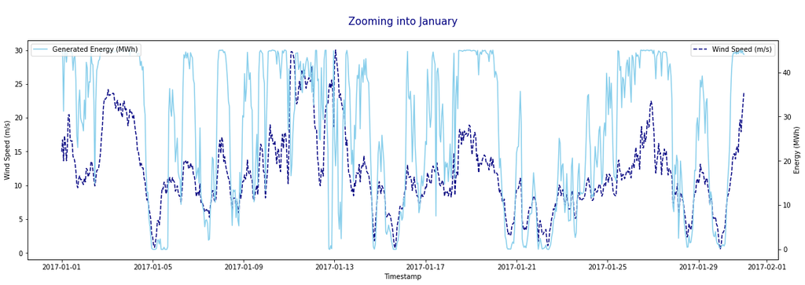

```python
energy_wind_Jan
```

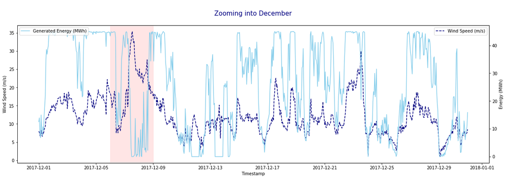

```python
energy_wind_Dec
```

Based on the analysis, we observed that certain periods of high energy generation are followed by periods of zero or low generation, despite wind speed levels permitting higher generation. For instance, from December 5th to December 9th. This presents an opportunity to store energy when such points are anticipated, thereby delaying wind turbine shutdowns, minimising curtailment, and mitigating the relatively costly expenses associated with turbine start-up and shutdown.

# Bridging the Gap: Exploring Solutions for Wind Energy Curtailment

## How can Wind Energy be better utilised?

In the Orkney Islands, two prominent energy challenges loom large. Firstly, a substantial portion of its renewable energy output is curtailed due to limited interconnection capacity with the mainland. This curtailment not only leads to lost revenue but also hinders progress towards the 2050 Target of Zero Net Carbon ([ESO Future Energy](https://www.nationalgrideso.com/future-energy)) by reducing the overall fraction of renewable energy utilised. Secondly, Orkney grapples with a significant fuel poverty issue, with over 60% of its households facing this challenge.

Fuel poverty is broadly defined as households unable to meet their energy needs at a reasonable cost. Specifically in Scotland, it exists if a household is required to spend more than 10% of its income to maintain a satisfactory heating regime. Contributing to Orkney's fuel poverty are factors such as lower-than-average income, with households earning around GBP 30,000 annually, meaning some households may spend more than GBP 3,000 annually on heating, showcasing the second factor which is high heating costs. The high heating costs are especially exacerbated in rural areas that rely more on electricity for heating. Additionally, energy costs in Orkney are generally higher than the average in Scotland and in the UK (Orkney's Fuel Poverty Strategy 2017). Other factors include the condition of its older housing stock, local climate conditions, and individual lifestyle choices, which contribute to higher than average electricity consumption compared to the rest of Scotland ([Scotland's Census Report - 2011 Census Data](https://www.scotlandscensus.gov.uk/documents/scotland-s-census-2022-rounded-population-estimates-data/)).

While addressing all these factors may seem daunting and cannot be all addressed within the scope of this report, there is a remarkable opportunity to tackle some of these challenges while addressing wind energy curtailment. By focusing on reducing wind energy curtailment, we can unlock numerous benefits for stakeholders. This includes higher revenue for wind farmers, lower energy costs for households, and reduced carbon emissions, contributing to the goal of achieving a Zero Net Carbon Future.

Various solutions exist, ranging from costly grid and infrastructure improvements to demand-response strategies. Our primary focus is on implementing domestic storage devices, and here is where Kaluza's role comes in. Kaluza provides flexible demand technology, allowing us to harness energy during peak wind periods and utilize it during peak demand times. This not only alleviates strain on the grid by minimizing turbine shutdowns but also reduces heating costs for households and opens up vast opportunities for improved living conditions in the Orkney community ([Kaluza Demand Response](https://www.kaluza.com/demand-response/)).

## How do we plan on achieving that?

Our plan revolves around revolutionizing the heating landscape in Orkney through the deployment of Kaluza's demand response (referred to as DR hereafter) technology. By retrofitting Kaluza's DR devices into electric quantum heaters and water boilers, we enable these appliances to automatically activate during periods of peak wind energy generation to store energy. Once the storage capacity reaches its limit, the devices switch off. In doing so, we effectively synchronize the demand for heating rooms and water with the timing of energy generation.

In this report, our focus is not the engineering and mechanics behind the integration and operation of the devices. Instead, our focus is on outlining the transformation plan, detailing our approach, highlighting the advantages for Kaluza, and the benefits for the Orkney community.

In 2017-2018, 41% of the households in Orkney rely on electricity for heating, 36% rely on oil, and 14% rely on solid fuel ([Orkney's Fuel Poverty Strategy 2017](https://www.orkney.gov.uk/Files/Housing/Housing%20Options/Housing%20Strategy/Fuel_Poverty_Strategy.pdf)).10% of the households have domestic renewable energy installations (Orkney Renewables Overview), assumed to fully rely on renewable energy for electricity consumption. Our primary focus will be on households that rely on electricity, as they already have a fertile base to work with, followed by those reliant on oil. This means that we have a **target segment of 77% of Orkney’s households**.

In our ideal scenario, we aim for a 100% penetration ratio within the target segment. However, practical considerations must be taken into account. Integrating **oil-reliant households** into the program entails replacing their heating systems, which incurs significant costs. Moreover, transitioning to a more expensive energy source presents an additional barrier. Realistically, we anticipate that only around **30% of this segment will opt to participate** to enjoy the more flexible control of their heating needs. Conversely, **electricity-reliant households** present a more straightforward opportunity for penetration. Since the installation of DR devices is the sole requirement, and they are already dependent on electricity, uptake is expected to be higher without additional financial burden. Nevertheless, we acknowledge that there will always be sceptics who may resist adopting new technologies for various reasons. Therefore, we expect an **80% uptake** of these households.

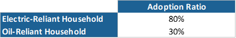

Over the span of 24 months, we intend to actively approach the local stakeholders, commencing with an intensified 6-month campaign aimed at fostering awareness about the advantages of renewable energy and energy flexibility. This comprehensive initiative will target households, as well as wind farmers who play a pivotal role in energy generation. Additionally, we will engage with the local council and governmental offices in Orkney to secure their support for our endeavour. Following this initial campaign phase, we will continue with smaller-scale marketing and engagement activities over the subsequent 18 months of the program.

In tandem with the marketing campaign, we will offer incentives to households to encourage the adoption of Kaluza's technology, details of which will be elaborated in the subsequent sections. Furthermore, we will implement a bonus scheme for our sales representatives based on their success in reaching the target segment and driving household adoption.

## Business Model

**Household Heating Needs**

Orkney Islands, with a population of 22,000 spread across over 10,000 households, averages 2.1 tenants per household. Using data from the National Records of Scotland Household report ([Report](https://www.nrscotland.gov.uk/files//statistics/household-projections/18/household-proj-18-report.pdf)), we further break down the distribution of households by tenant count and type, assuming an **average of 3 heaters required per household** to maintain reasonable heating needs daily.

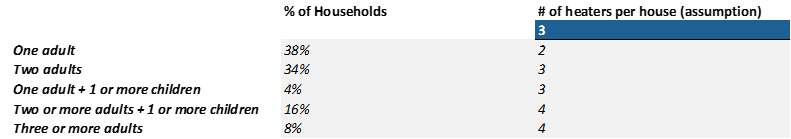

Therefore, we needed to estimate the number of operating hours per day for each heater. To do this, we took into account the varying heating requirements throughout the calendar months, considering the temperature fluctuations. Additionally, given that the buildings in Orkney are relatively old and may not have high energy efficiency scores, we factored in these considerations. This analysis led us to an **average of 2.7 hours per day for each heater across all calendar months**.

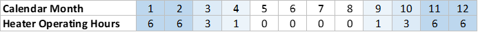

As for water boilers, the estimated hot water usage is 60 litres per day per person [(Hot Water Cylinder Calculator)](https://www.hotwater.org.uk/hot-water-cylinder-calculator/). For an average sized households, this indicates the need for **126 litres of hot water per day**. Additionally, we estimate a ** water cylinder’s usage of electric energy to be one hour per day**.

**Revenues**

Kaluza's revenue stream will be derived from two sources. Firstly, revenue will be generated through the sale and installation of our demand response (DR) devices. Secondly, Kaluza will receive fees from wind farmers for facilitating the sale of energy that would otherwise be curtailed. This dual revenue model ensures a sustainable income stream, even after the completion of the 24 months active implementation.

**1. Kaluza’s DR Devices Sale**

Each DR device is priced at £100, with an additional installation cost of £90 (£30 per hour for 3 hours). Therefore, the total upfront price for the DR device, including installation, is £190. Considering that one device is needed for each heating appliance, including one for the hot water cylinder and three for the heaters, a total of four devices are required per household; adding up to £760 upfront fee per household. The full £760 fee per household will be recognized as revenue, and the installation costs will be accounted for as the cost of goods sold, deducted from the gross margin.

**2. Wind Farmers Fee** The plan is for Kaluza to negotiate a fee with wind farmers based on a percentage of the revenue generated from selling the wind energy that would have otherwise been curtailed. This fee will vary throughout the 24-month project implementation period and the subsequent run-off month, aligning with the investment in campaigning and marketing covered by Kaluza.

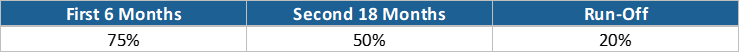

**Energy Prices and Consumption**

To provide a comprehensive overview of the revenue picture, we must also consider the current energy consumption and pricing experienced by households, as well as the anticipated changes with the introduction of demand response systems.

**1. Energy Prices**

Currently, in 2018, the average prices for different energy sources are as follows: 17.58 pence per kWh of electricity, derived from the [Quarterly Energy Prices Report](https://assets.publishing.service.gov.uk/media/5c9b80f040f0b633fd3b0c11/QEP_Q4_2018.pdf), and 53.84 pence per litre of heating oil, obtained from the [Office of National Statistics Inflation and Price Indices Report](https://www.ons.gov.uk/economy/inflationandpriceindices/timeseries/kj5u/mm23), which translates to an electric equivalent of approximately 5.98 pence per kWh. Clearly, the price of oil heating is significantly lower than that of electricity, whether renewable or non-renewable based. Therefore, we plan to agree with the wind farmers and council to offer the wind energy through the DR devices facility at different rates for the electric-reliant households and the oil-reliant households.

We believe that a reasonable price for the currently curtailed wind energy is 12 pence per KWh, which is around the average of the different heating sources currently, and around 70% of the electricity price. Ideally, taking into account an average of the households’ current energy price and the curtailed energy price, we would want to then sell wind energy to the electric-reliant households at 15.26 pence per KWh, and to the oil-reliant households at 8.30 pence per KWh. The price for the electric-reliant households would be attractive as it is ~15% lower than the current energy prices. While the target price for the oil-reliant households is excessively higher than their current energy price (+40%), which would make it impossible to get any of them to adopt the new technology and energy source. Therefore, we opt for reducing their wind energy price to 6.64 pence per KWh, which is around only 10% higher than their current price, which we believe is a reasonable increase for better quality and more flexible heating source.

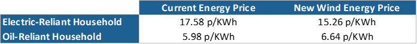

**2. Energy Consumption for Heating Purposes**

Presently, we estimate that households consume an average of 628 kWh per month for heating, split into 537 kWh for heating and 91 kWh for hot water. This estimation was derived from an electric-based household scenario, relying on quantum heaters and water cylinders. Specifically, we considered the Dimplex Quantum heater, which requires 2.22 kW of power to operate [Heater Specs](https://www.electricpoint.com/dimplex-quantum-qm050-quantum-storage-heater-500w-energy-saving.html), and the Megaflo water cylinder with a capacity of 210 litres and needing 3 kW of power to operate [Water Cylinder Specs](https://electricaldealsdirect.co.uk/media/pdfs/MEGAFLO_Eco_Technical_Data.pdf). Combining these figures with our assumptions on daily heating needs per household, we arrive at a total of 628 kWh per month.

$\small{\text{Heating Energy Consumption per Day = 3 heaters per household} \times \text{2.7 hrs operating} \times \text{2.22 KWh energy consumption = } \textbf{18 KWh/day}}$

$\small{\text{Hot Water Energy Consumption per Day = 1 water cylinder per household} \times \text{1 hrs operating} \times \text{3 KWh energy consumption = } \textbf{3 KWh/day}}$

With increased flexibility and reduced costs, we anticipate a rise in energy usage, particularly among the electric-reliant households, where the new energy source will be more cost-effective than their current one. For a portion of these households, maintaining their current expenditure levels may lead to a 15% increase in energy consumption for heating and hot water. Conversely, some households, mindful of the fuel poverty challenge, may opt to reduce their expenditure by closely monitoring their consumption at pre-demand-response levels. We estimate that approximately 65% of electric-reliant households will fall into the former category, while the remaining 35% will belong to the latter. This projection yields an average increase of 62 kWh per month per household for electric-reliant households.